# YOLOv8 Food Detection Fine-tuning (Multi-Dataset Merge)

여러 Roboflow 프로젝트의 데이터셋을 병합하여 YOLOv8n을 fine-tune하고 ONNX로 export합니다.

**기존 클래스가 사라지는 문제(Catastrophic Forgetting)를 방지하기 위해 모든 데이터셋을 하나로 합쳐서 학습합니다.**

**런타임 → 런타임 유형 변경 → GPU(T4)** 로 설정 후 실행하세요.

## 1. 환경 설정

```python
!pip install ultralytics roboflow pyyaml -q
```

```
   ━━━━━━━━━━━━━━━━━━━━━━━━━━━━━━━━━━━━━━━━ 1.2/1.2 MB 23.5 MB/s eta 0:00:00
   ━━━━━━━━━━━━━━━━━━━━━━━━━━━━━━━━━━━━━━━━ 95.8/95.8 kB 11.5 MB/s eta 0:00:00
   ━━━━━━━━━━━━━━━━━━━━━━━━━━━━━━━━━━━━━━━━ 66.8/66.8 kB 7.8 MB/s eta 0:00:00
   ━━━━━━━━━━━━━━━━━━━━━━━━━━━━━━━━━━━━━━━━ 49.9/49.9 MB 49.3 MB/s eta 0:00:00
   ━━━━━━━━━━━━━━━━━━━━━━━━━━━━━━━━━━━━━━━━ 1.5/1.5 MB 95.8 MB/s eta 0:00:00
   ━━━━━━━━━━━━━━━━━━━━━━━━━━━━━━━━━━━━━━━━ 5.5/5.5 MB 145.7 MB/s eta 0:00:00
```

```python
import torch
print(f'GPU: {torch.cuda.get_device_name(0)}')
print(f'CUDA available: {torch.cuda.is_available()}')
```

```
GPU: NVIDIA A100-SXM4-40GB
CUDA available: True
```

## 2. 데이터셋 다운로드

Roboflow에서 여러 프로젝트의 데이터셋을 다운로드합니다.

### 데이터셋 목록 설정

`DATASETS` 리스트에 사용할 데이터셋을 추가하세요. 각 항목은 `(workspace, project, version)` 튜플입니다.

```python
from roboflow import Roboflow

# === Roboflow API 키를 입력하세요 ===
API_KEY = "BxXjP7HwKQQyXe8JRomz"

# === 병합할 데이터셋 목록 ===
# (workspace, project, version) 튜플로 추가
DATASETS = [
    # 한식 데이터셋
    ("heasun8583-gmail-com", "korean-food_yolov5", 6),
    ("anonymous-fhuzh", "korean-food-iaryc", 3),
    ("hamza-ic0tt", "food-class", 2),
    ("rabia-qztrg", "food-k7fpo", 5),
    ("jungyang", "what-the-food-9wdgr", 6),
    ("seoyoung-lee-ashwk", "-fjkq0", 1,),
]

rf = Roboflow(api_key=API_KEY)

downloaded = []
failed = []

for workspace, project_name, version_num in DATASETS:
    try:
        print(f'\n--- Downloading: {workspace}/{project_name} v{version_num} ---')
        project = rf.workspace(workspace).project(project_name)
        version = project.version(version_num)
        dataset = version.download("yolov8")
        downloaded.append({
            'workspace': workspace,
            'project': project_name,
            'version': version_num,
            'dataset': dataset
        })
        print(f'  ✓ Location: {dataset.location}')
    except Exception as e:
        error_msg = f'{workspace}/{project_name} v{version_num}'
        failed.append(error_msg)
        print(f'  ✗ 실패: {str(e)}')

print(f'\n=== 다운로드 결과 ===')
print(f'성공: {len(downloaded)}개')
print(f'실패: {len(failed)}개')

if downloaded:
    print('\n✓ 다운로드 성공한 데이터셋:')
    for item in downloaded:
        print(f"  - {item['workspace']}/{item['project']} v{item['version']}")
        print(f"    위치: {item['dataset'].location}")

if failed:
    print('\n✗ 다운로드 실패한 데이터셋:')
    for item in failed:
        print(f"  - {item}")
```

```
--- Downloading: heasun8583-gmail-com/korean-food_yolov5 v6 ---
loading Roboflow workspace...
loading Roboflow project...
```

```
Downloading Dataset Version Zip in Korean-Food_yolov5-6 to yolov8:: 100%|██████████| 67638/67638 [00:01<00:00, 61379.94it/s]
```

```
Extracting Dataset Version Zip to Korean-Food_yolov5-6 in yolov8:: 100%|██████████| 5271/5271 [00:00<00:00, 10669.57it/s]
```

```
Creating new Ultralytics Settings v0.0.6 file ✅
View Ultralytics Settings with 'yolo settings' or at '/root/.config/Ultralytics/settings.json'
Update Settings with 'yolo settings key=value', i.e. 'yolo settings runs_dir=path/to/dir'. For help see https://docs.ultralytics.com/quickstart/#ultralytics-settings.
  ✓ Location: /content/Korean-Food_yolov5-6

--- Downloading: anonymous-fhuzh/korean-food-iaryc v3 ---
loading Roboflow workspace...
loading Roboflow project...
```

```
Downloading Dataset Version Zip in korean-food-3 to yolov8:: 100%|██████████| 1214183/1214183 [00:14<00:00, 84620.47it/s]
```

```
Extracting Dataset Version Zip to korean-food-3 in yolov8:: 100%|██████████| 16214/16214 [00:03<00:00, 4698.82it/s]
```

```
  ✓ Location: /content/korean-food-3

--- Downloading: hamza-ic0tt/food-class v2 ---
loading Roboflow workspace...
loading Roboflow project...
```

```
Downloading Dataset Version Zip in food-class-2 to yolov8:: 100%|██████████| 248075/248075 [00:03<00:00, 82343.43it/s]
```

```
Extracting Dataset Version Zip to food-class-2 in yolov8:: 100%|██████████| 11396/11396 [00:01<00:00, 9092.00it/s]
```

```
  ✓ Location: /content/food-class-2

--- Downloading: rabia-qztrg/food-k7fpo v5 ---
loading Roboflow workspace...
```

```
loading Roboflow project...
```

```
Downloading Dataset Version Zip in food-5 to yolov8:: 100%|██████████| 64034/64034 [00:01<00:00, 45311.66it/s]
```

```
Extracting Dataset Version Zip to food-5 in yolov8:: 100%|██████████| 2322/2322 [00:00<00:00, 7843.29it/s]
```

```
  ✓ Location: /content/food-5

--- Downloading: jungyang/what-the-food-9wdgr v6 ---
loading Roboflow workspace...
loading Roboflow project...
```

```
Downloading Dataset Version Zip in what-the-food-6 to yolov8:: 100%|██████████| 1184873/1184873 [00:17<00:00, 67351.99it/s]
```

```
Extracting Dataset Version Zip to what-the-food-6 in yolov8:: 100%|██████████| 45938/45938 [00:05<00:00, 8426.43it/s]
```

```
  ✓ Location: /content/what-the-food-6

--- Downloading: seoyoung-lee-ashwk/-fjkq0 v1 ---
loading Roboflow workspace...
loading Roboflow project...
```

```
Downloading Dataset Version Zip in 통합한식-1 to yolov8:: 100%|██████████| 583081/583081 [00:06<00:00, 84663.07it/s]
```

```
Extracting Dataset Version Zip to 통합한식-1 in yolov8:: 100%|██████████| 43802/43802 [00:04<00:00, 10310.07it/s]
```

```
  ✓ Location: /content/통합한식-1

=== 다운로드 결과 ===
성공: 6개
실패: 0개

✓ 다운로드 성공한 데이터셋:
  - heasun8583-gmail-com/korean-food_yolov5 v6
    위치: /content/Korean-Food_yolov5-6
  - anonymous-fhuzh/korean-food-iaryc v3
    위치: /content/korean-food-3
  - hamza-ic0tt/food-class v2
    위치: /content/food-class-2
  - rabia-qztrg/food-k7fpo v5
    위치: /content/food-5
  - jungyang/what-the-food-9wdgr v6
    위치: /content/what-the-food-6
  - seoyoung-lee-ashwk/-fjkq0 v1
    위치: /content/통합한식-1
```

```python
from pprint import pprint
pprint(f"{downloaded = }")
print("\n\n")
print(f"{downloaded[0]['dataset'].location = }")
```

```
("downloaded = [{'workspace': 'heasun8583-gmail-com', 'project': "
 "'korean-food_yolov5', 'version': 6, 'dataset': "
 "<roboflow.core.dataset.Dataset object at 0x788267605ac0>}, {'workspace': "
 "'anonymous-fhuzh', 'project': 'korean-food-iaryc', 'version': 3, 'dataset': "
 "<roboflow.core.dataset.Dataset object at 0x788266d37680>}, {'workspace': "
 "'hamza-ic0tt', 'project': 'food-class', 'version': 2, 'dataset': "
 "<roboflow.core.dataset.Dataset object at 0x788266e2db80>}, {'workspace': "
 "'rabia-qztrg', 'project': 'food-k7fpo', 'version': 5, 'dataset': "
 "<roboflow.core.dataset.Dataset object at 0x7882674fd8e0>}, {'workspace': "
 "'jungyang', 'project': 'what-the-food-9wdgr', 'version': 6, 'dataset': "
 "<roboflow.core.dataset.Dataset object at 0x788259f8c410>}, {'workspace': "
 "'seoyoung-lee-ashwk', 'project': '-fjkq0', 'version': 1, 'dataset': "
 '<roboflow.core.dataset.Dataset object at 0x78826735d190>}]')



downloaded[0]['dataset'].location = '/content/Korean-Food_yolov5-6'
```

## 3. 데이터셋 병합

각 데이터셋의 클래스를 통합 클래스 맵으로 재매핑하고, 이미지와 라벨을 하나의 디렉터리에 병합합니다.

```python
import os
import yaml
import shutil
from pathlib import Path

MERGED_DIR = Path('/content/merged_dataset')

# === 클래스명 정규화 ===
# 중복/동의어 클래스를 하나의 대표명으로 통합합니다.
# key: 원래 이름, value: 대표 이름
CLASS_ALIASES = {
    # 대소문자/표기법 차이
    'kimchi': 'Kimchi',
    'Rice': 'rice',
    'japchae': 'Japchae',
    'chicken': 'Chicken',
    'pizza': 'Pizza',
    'pasta': 'Pasta',
    'ramyun': 'ramyeon',

    # 영어명 ↔ 로마자 한국어명
    'Jeyukbokkeum': 'jeyuk bokkeum',
    'Eomukbokkeum': 'eomuk bokkeum',
    'DoenjangJjigae': 'doenjang jjigae',
    'SundubuJjigae': 'sundubu jjigae',
    'Yukgaejang': 'spicy yuke jang',
    'miyeok guk': 'seaweed soup',
    'myeolchi bokkeum': 'stir-fried anchovies',
    'jokbal': 'pig hocks',
    'samgyeopsal': 'pork belly',
    'Kongnamulmuchim': 'seasoned bean sprouts',
    'kongnamul muchim': 'seasoned bean sprouts',
    'Seasoned bean sprouts': 'seasoned bean sprouts',
    'Kongnamulguk': 'bean sprout soup',
    'KimchiJjim': 'kimchi jjigae',

    # 의미 없는 클래스 (제거 대상 — None으로 매핑)
    'Finger': None,
    'sigm': None,
    'sog': None,
}


def normalize_class_name(name):
    """클래스명을 정규화합니다. None을 반환하면 해당 클래스는 제거됩니다."""
    return CLASS_ALIASES.get(name, name)


def get_location(ds_entry):
    """downloaded 항목에서 location 문자열을 추출합니다."""
    if isinstance(ds_entry, dict):
        return ds_entry['dataset'].location
    if isinstance(ds_entry, str):
        return ds_entry
    return ds_entry.location


def load_class_names(dataset_location):
    """data.yaml에서 클래스 이름 목록을 읽어옵니다."""
    yaml_path = os.path.join(dataset_location, 'data.yaml')
    with open(yaml_path, 'r') as f:
        data = yaml.safe_load(f)
    names = data.get('names', [])
    if isinstance(names, dict):
        names = [names[k] for k in sorted(names.keys())]
    return names


# 1) 모든 데이터셋에서 클래스 이름을 수집하여 통합 클래스 맵 생성
unified_names = []  # 통합 클래스 리스트 (순서 = ID)
dataset_class_maps = []  # 각 데이터셋별 {원래ID -> 통합ID} 매핑
dataset_locations = []  # 경로 문자열 리스트
skipped_classes = set()  # 제거된 클래스

for ds_entry in downloaded:
    location = get_location(ds_entry)
    dataset_locations.append(location)
    names = load_class_names(location)
    class_map = {}
    for old_id, name in enumerate(names):
        normalized = normalize_class_name(name)
        if normalized is None:
            skipped_classes.add(name)
            class_map[old_id] = None
            continue
        if normalized not in unified_names:
            unified_names.append(normalized)
        new_id = unified_names.index(normalized)
        class_map[old_id] = new_id
    dataset_class_maps.append(class_map)
    print(f'{location}: {len(names)} classes -> mapped to unified IDs')

print(f'\n통합 클래스 수: {len(unified_names)}')
if skipped_classes:
    print(f'제거된 클래스: {skipped_classes}')
print()
for i, name in enumerate(unified_names):
    print(f'  {i}: {name}')
```

```
/content/Korean-Food_yolov5-6: 53 classes -> mapped to unified IDs
/content/korean-food-3: 53 classes -> mapped to unified IDs
/content/food-class-2: 51 classes -> mapped to unified IDs
/content/food-5: 74 classes -> mapped to unified IDs
/content/what-the-food-6: 10 classes -> mapped to unified IDs
/content/통합한식-1: 60 classes -> mapped to unified IDs

통합 클래스 수: 221
제거된 클래스: {'sog', 'sigm', 'Finger'}

  0: Braised lotus roots
  1: Dongchimi
  2: Japchae
  3: Kimchi stew
  4: Kimchi
```

[output cut: 216 more lines]

```python
def remap_labels(src_label_path, dst_label_path, class_map):
    """YOLO 라벨 파일의 class ID를 통합 맵에 맞게 재매핑합니다."""
    with open(src_label_path, 'r') as f:
        lines = f.readlines()

    remapped = []
    for line in lines:
        parts = line.strip().split()
        if len(parts) < 5:
            continue
        old_class = int(parts[0])
        if old_class not in class_map:
            continue
        new_class = class_map[old_class]
        if new_class is None:
            continue
        parts[0] = str(new_class)
        remapped.append(' '.join(parts))

    with open(dst_label_path, 'w') as f:
        f.write('\n'.join(remapped) + '\n')


def merge_split(split, dataset_idx, dataset_location, class_map):
    """하나의 split(train/valid/test)을 병합 디렉터리에 복사합니다."""
    src_img_dir = Path(dataset_location) / split / 'images'
    src_lbl_dir = Path(dataset_location) / split / 'labels'

    if not src_img_dir.exists():
        return 0

    dst_img_dir = MERGED_DIR / split / 'images'
    dst_lbl_dir = MERGED_DIR / split / 'labels'
    dst_img_dir.mkdir(parents=True, exist_ok=True)
    dst_lbl_dir.mkdir(parents=True, exist_ok=True)

    count = 0
    for img_file in src_img_dir.iterdir():
        if img_file.suffix.lower() not in ('.jpg', '.jpeg', '.png', '.bmp', '.webp'):
            continue

        prefix = f'ds{dataset_idx}_'
        new_img_name = prefix + img_file.name
        new_lbl_name = prefix + img_file.stem + '.txt'

        shutil.copy2(img_file, dst_img_dir / new_img_name)

        src_lbl = src_lbl_dir / (img_file.stem + '.txt')
        if src_lbl.exists():
            remap_labels(src_lbl, dst_lbl_dir / new_lbl_name, class_map)
        else:
            (dst_lbl_dir / new_lbl_name).touch()

        count += 1
    return count


# 기존 병합 디렉터리 초기화
if MERGED_DIR.exists():
    shutil.rmtree(MERGED_DIR)

# dataset_locations를 사용 (cell-7에서 생성됨)
for idx, (location, class_map) in enumerate(zip(dataset_locations, dataset_class_maps)):
    print(f'\n--- Merging dataset {idx}: {location} ---')
    for split in ['train', 'valid', 'test']:
        n = merge_split(split, idx, location, class_map)
        if n > 0:
            print(f'  {split}: {n} images')

# 통합 data.yaml 생성
merged_yaml = {
    'train': str(MERGED_DIR / 'train' / 'images'),
    'val': str(MERGED_DIR / 'valid' / 'images'),
    'nc': len(unified_names),
    'names': unified_names,
}

test_dir = MERGED_DIR / 'test' / 'images'
if test_dir.exists() and any(test_dir.iterdir()):
    merged_yaml['test'] = str(test_dir)

yaml_path = MERGED_DIR / 'data.yaml'
with open(yaml_path, 'w') as f:
    yaml.dump(merged_yaml, f, default_flow_style=False, allow_unicode=True)

print(f'\n병합 완료!')
print(f'  총 클래스: {len(unified_names)}')
for split in ['train', 'valid', 'test']:
    img_dir = MERGED_DIR / split / 'images'
    if img_dir.exists():
        print(f'  {split}: {len(list(img_dir.iterdir()))} images')
print(f'  data.yaml: {yaml_path}')
```

```
--- Merging dataset 0: /content/Korean-Food_yolov5-6 ---
  train: 2460 images
  valid: 171 images

--- Merging dataset 1: /content/korean-food-3 ---
  train: 7404 images
  valid: 470 images
  test: 227 images

--- Merging dataset 2: /content/food-class-2 ---
  train: 5487 images
  valid: 124 images
  test: 81 images

--- Merging dataset 3: /content/food-5 ---
  train: 1011 images
  valid: 98 images
  test: 46 images

--- Merging dataset 4: /content/what-the-food-6 ---
  train: 20094 images
  valid: 1912 images
  test: 957 images

--- Merging dataset 5: /content/통합한식-1 ---
  train: 15232 images
  valid: 4387 images
  test: 2276 images

병합 완료!
  총 클래스: 221
  train: 51688 images
  valid: 7162 images
  test: 3587 images
  data.yaml: /content/merged_dataset/data.yaml
```

### 병합 결과 검증

```python
import random
from collections import Counter

# 라벨 분포 확인
class_counts = Counter()
label_dir = MERGED_DIR / 'train' / 'labels'

for lbl_file in label_dir.iterdir():
    with open(lbl_file, 'r') as f:
        for line in f:
            parts = line.strip().split()
            if parts:
                class_counts[int(parts[0])] += 1

print(f'Train 라벨 분포 ({sum(class_counts.values())} annotations):')
print('-' * 40)
for class_id in sorted(class_counts.keys()):
    name = unified_names[class_id] if class_id < len(unified_names) else '???'
    print(f'  [{class_id:3d}] {name:30s} {class_counts[class_id]:5d}')

# train에 없는 클래스 확인
missing = [i for i in range(len(unified_names)) if i not in class_counts]
if missing:
    print(f'\n주의: train에 없는 클래스 {len(missing)}개:')
    for i in missing:
        print(f'  [{i}] {unified_names[i]}')

    # valid/test에서 해당 클래스를 포함하는 이미지를 train으로 이동
    missing_set = set(missing)
    moved_count = 0

    for split in ['valid', 'test']:
        split_lbl_dir = MERGED_DIR / split / 'labels'
        split_img_dir = MERGED_DIR / split / 'images'
        if not split_lbl_dir.exists():
            continue

        train_lbl_dir = MERGED_DIR / 'train' / 'labels'
        train_img_dir = MERGED_DIR / 'train' / 'images'

        for lbl_file in list(split_lbl_dir.iterdir()):
            with open(lbl_file, 'r') as f:
                classes_in_file = set()
                for line in f:
                    parts = line.strip().split()
                    if parts:
                        classes_in_file.add(int(parts[0]))

            # 이 파일이 missing 클래스를 하나라도 포함하면 train으로 이동
            if classes_in_file & missing_set:
                # 라벨 이동
                shutil.move(str(lbl_file), str(train_lbl_dir / lbl_file.name))
                # 대응하는 이미지 찾아서 이동
                stem = lbl_file.stem
                for ext in ('.jpg', '.jpeg', '.png', '.bmp', '.webp'):
                    img_file = split_img_dir / (stem + ext)
                    if img_file.exists():
                        shutil.move(str(img_file), str(train_img_dir / img_file.name))
                        break
                moved_count += 1

    print(f'\n{moved_count}개 이미지를 valid/test → train으로 이동했습니다.')

    # 재검증
    class_counts2 = Counter()
    for lbl_file in (MERGED_DIR / 'train' / 'labels').iterdir():
        with open(lbl_file, 'r') as f:
            for line in f:
                parts = line.strip().split()
                if parts:
                    class_counts2[int(parts[0])] += 1

    still_missing = [i for i in range(len(unified_names)) if i not in class_counts2]
    if still_missing:
        print(f'\n여전히 train에 없는 클래스: {[unified_names[i] for i in still_missing]}')
        print('이 클래스들은 어떤 split에도 데이터가 없습니다. 제거를 고려하세요.')
    else:
        print(f'모든 {len(unified_names)}개 클래스에 학습 데이터 있음')
else:
    print(f'\n모든 {len(unified_names)}개 클래스에 학습 데이터 있음')
```

```
Train 라벨 분포 (69386 annotations):
----------------------------------------
  [  0] Braised lotus roots              198
  [  1] Dongchimi                        132
  [  2] Japchae                          562
  [  3] Kimchi stew                      255
  [  4] Kimchi                          2251
  [  5] Korean rib                       111
  [  6] Korean style raw beef            186
  [  7] seasoned bean sprouts           2907
  [  8] Udon                             240
  [  9] baek Kimchi                      189
  [ 10] banquet noodles                  198
  [ 11] bean sprout soup                2133
  [ 12] beef-bone soup                   108
  [ 13] bellflower greens                201
  [ 14] bibimbap                         276
  [ 15] boiled fish paste soup           174
  [ 16] budaejjigae                      258
  [ 17] bulgogi                          172
  [ 18] chonggak Kimchi                  294
  [ 19] cucumber kimchi                  282
  [ 20] cup rice                         216
  [ 21] dried pollack soup               180
  [ 22] eel                              192
  [ 23] fried rice                       192
  [ 24] green onion Kimchi               195
  [ 25] grilled mackerel                 228
  [ 26] janjorim                         240
  [ 27] jeyuk bokkeum                   2235
  [ 28] memil soba                       120
  [ 29] miso soup                        252
  [ 30] mixed rice                        36
  [ 31] nabak Kimchi                     309
  [ 32] naengMyeon                       231
  [ 33] pickled sesame leaf              132
  [ 34] pig hocks                        555
  [ 35] pork belly                       413
  [ 36] radish Kimchi                    339
  [ 37] radish kimchi                      3
```

[output cut: 173 more lines]

```
  [217] tteokbokki                       546
  [218] twigim                           176
  [219] yangpa jangajji                  169
  [220] yukhoe                           398

주의: train에 없는 클래스 6개:
  [119] etli kuru fasulye
  [138] lahmacun
  [167] tavuklu yemek
  [168] taze fasulye
  [170] yaprak sarma
  [180] bossam

11개 이미지를 valid/test → train으로 이동했습니다.
모든 221개 클래스에 학습 데이터 있음
```

## 4. YOLOv8n Fine-tune

병합된 데이터셋으로 학습합니다.

**BASE_MODEL 선택:**

- `yolov8n.pt`: COCO pretrained 베이스 (처음부터 학습)
- 기존 `best.pt`: 이전에 학습한 모델 베이스 (추가 학습, 더 빠름)

```python
from ultralytics import YOLO

# === 베이스 모델 선택 ===
# 처음부터 학습하려면 'yolov8n.pt'
# 기존 모델에서 이어서 학습하려면 기존 best.pt 경로
BASE_MODEL = 'yolov8n.pt'

model = YOLO(BASE_MODEL)

results = model.train(
    data=str(MERGED_DIR / 'data.yaml'),
    epochs=80,
    imgsz=640,
    batch=16,
    patience=15,
    device=0,
    pretrained=True,
    optimizer='AdamW',
    lr0=0.001,
    lrf=0.01,
    project='food_detect',
    name='yolov8n_merged',
)
```

```
Downloading https://github.com/ultralytics/assets/releases/download/v8.4.0/yolov8n.pt to 'yolov8n.pt': 100% ━━━━━━━━━━━━ 6.2MB 79.5MB/s 0.1s
Ultralytics 8.4.33 🚀 Python-3.12.13 torch-2.10.0+cu128 CUDA:0 (NVIDIA A100-SXM4-40GB, 40441MiB)
engine/trainer: agnostic_nms=False, amp=True, angle=1.0, augment=False, auto_augment=randaugment, batch=16, bgr=0.0, box=7.5, cache=False, cfg=None, classes=None, close_mosaic=10, cls=0.5, compile=False, conf=None, copy_paste=0.0, copy_paste_mode=flip, cos_lr=False, cutmix=0.0, data=/content/merged_…
Downloading https://ultralytics.com/assets/Arial.ttf to '/root/.config/Ultralytics/Arial.ttf': 100% ━━━━━━━━━━━━ 755.1KB 16.7MB/s 0.0s
Overriding model.yaml nc=80 with nc=221

                   from  n    params  module                                       arguments
  0                  -1  1       464  ultralytics.nn.modules.conv.Conv             [3, 16, 3, 2]
  1                  -1  1      4672  ultralytics.nn.modules.conv.Conv             [16, 32, 3, 2]
  2                  -1  1      7360  ultralytics.nn.modules.block.C2f             [32, 32, 1, True]
  3                  -1  1     18560  ultralytics.nn.modules.conv.Conv             [32, 64, 3, 2]
  4                  -1  2     49664  ultralytics.nn.modules.block.C2f             [64, 64, 2, True]
  5                  -1  1     73984  ultralytics.nn.modules.conv.Conv             [64, 128, 3, 2]
  6                  -1  2    197632  ultralytics.nn.modules.block.C2f             [128, 128, 2, True]
  7                  -1  1    295424  ultralytics.nn.modules.conv.Conv             [128, 256, 3, 2]
  8                  -1  1    460288  ultralytics.nn.modules.block.C2f             [256, 256, 1, True]
  9                  -1  1    164608  ultralytics.nn.modules.block.SPPF            [256, 256, 5]
 10                  -1  1         0  torch.nn.modules.upsampling.Upsample         [None, 2, 'nearest']
 11             [-1, 6]  1         0  ultralytics.nn.modules.conv.Concat           [1]
 12                  -1  1    148224  ultralytics.nn.modules.block.C2f             [384, 128, 1]
 13                  -1  1         0  torch.nn.modules.upsampling.Upsample         [None, 2, 'nearest']
 14             [-1, 4]  1         0  ultralytics.nn.modules.conv.Concat           [1]
 15                  -1  1     37248  ultralytics.nn.modules.block.C2f             [192, 64, 1]
 16                  -1  1     36992  ultralytics.nn.modules.conv.Conv             [64, 64, 3, 2]
 17            [-1, 12]  1         0  ultralytics.nn.modules.conv.Concat           [1]
 18                  -1  1    123648  ultralytics.nn.modules.block.C2f             [192, 128, 1]
 19                  -1  1    147712  ultralytics.nn.modules.conv.Conv             [128, 128, 3, 2]
 20             [-1, 9]  1         0  ultralytics.nn.modules.conv.Concat           [1]
 21                  -1  1    493056  ultralytics.nn.modules.block.C2f             [384, 256, 1]
 22        [15, 18, 21]  1   1123267  ultralytics.nn.modules.head.Detect           [221, 16, None, [64, 128, 256]]
Model summary: 130 layers, 3,382,803 parameters, 3,382,787 gradients, 9.9 GFLOPs

Transferred 319/355 items from pretrained weights
Freezing layer 'model.22.dfl.conv.weight'
AMP: running Automatic Mixed Precision (AMP) checks...
Downloading https://github.com/ultralytics/assets/releases/download/v8.4.0/yolo26n.pt to 'yolo26n.pt': 100% ━━━━━━━━━━━━ 5.3MB 71.3MB/s 0.1s
AMP: checks passed ✅
train: Fast image access ✅ (ping: 0.0±0.0 ms, read: 1762.7±874.7 MB/s, size: 54.6 KB)
train: Scanning /content/merged_dataset/train/labels... 51699 images, 387 backgrounds, 0 corrupt: 100% ━━━━━━━━━━━━ 51699/51699 1.5Kit/s 33.7s
train: New cache created: /content/merged_dataset/train/labels.cache
```

[output cut: 581 more lines]

```
         saengseon gui        210        469      0.934      0.951      0.977      0.819
            samgyetang        105        122       0.97      0.967      0.967      0.825
              sannakji        118        126      0.932      0.873      0.926      0.707
      sigeumchi muchim         62         63      0.901      0.968      0.971      0.852
                  soju        158        169      0.897      0.953      0.969      0.793
                sundae         42         44       0.85      0.932      0.927      0.804
         sundae gukbap        254        254       0.99      0.996      0.995      0.908
                 suyuk         85        111      0.971      0.964      0.986      0.895
             tangsuyuk        130        230      0.938      0.986      0.984      0.778
            tteokbokki        154        160      0.739      0.781      0.734      0.701
                twigim         53         53      0.996          1      0.995      0.956
       yangpa jangajji         64         64      0.893          1      0.994      0.983
                yukhoe        111        116      0.917       0.94      0.956      0.797
Speed: 0.1ms preprocess, 0.6ms inference, 0.0ms loss, 1.1ms postprocess per image
Results saved to /content/runs/detect/food_detect/yolov8n_merged
```

## 5. 학습 결과 확인

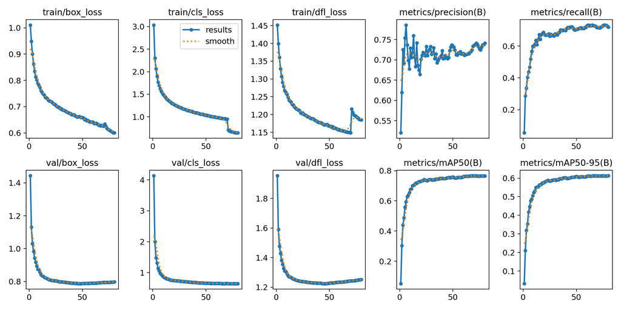

```python
from IPython.display import Image, display

result_dir = 'runs/detect/food_detect/yolov8n_merged'

# 학습 곡선
display(Image(filename=f'{result_dir}/results.png', width=800))
```

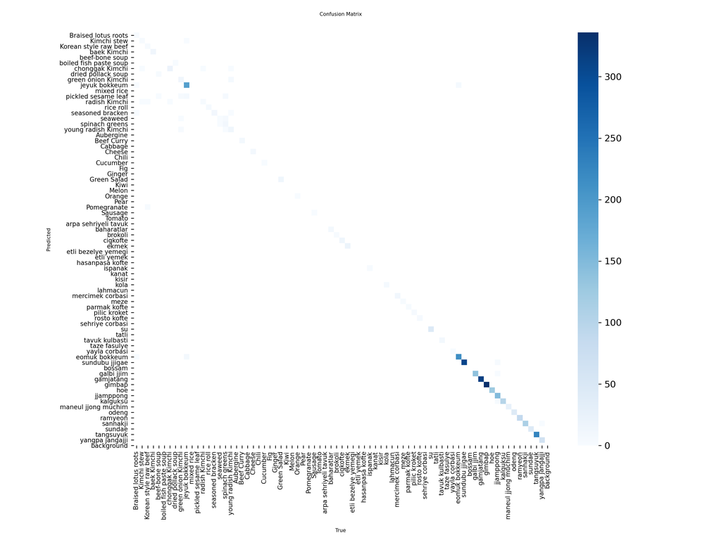

```python
# Confusion matrix
display(Image(filename=f'{result_dir}/confusion_matrix.png', width=600))
```

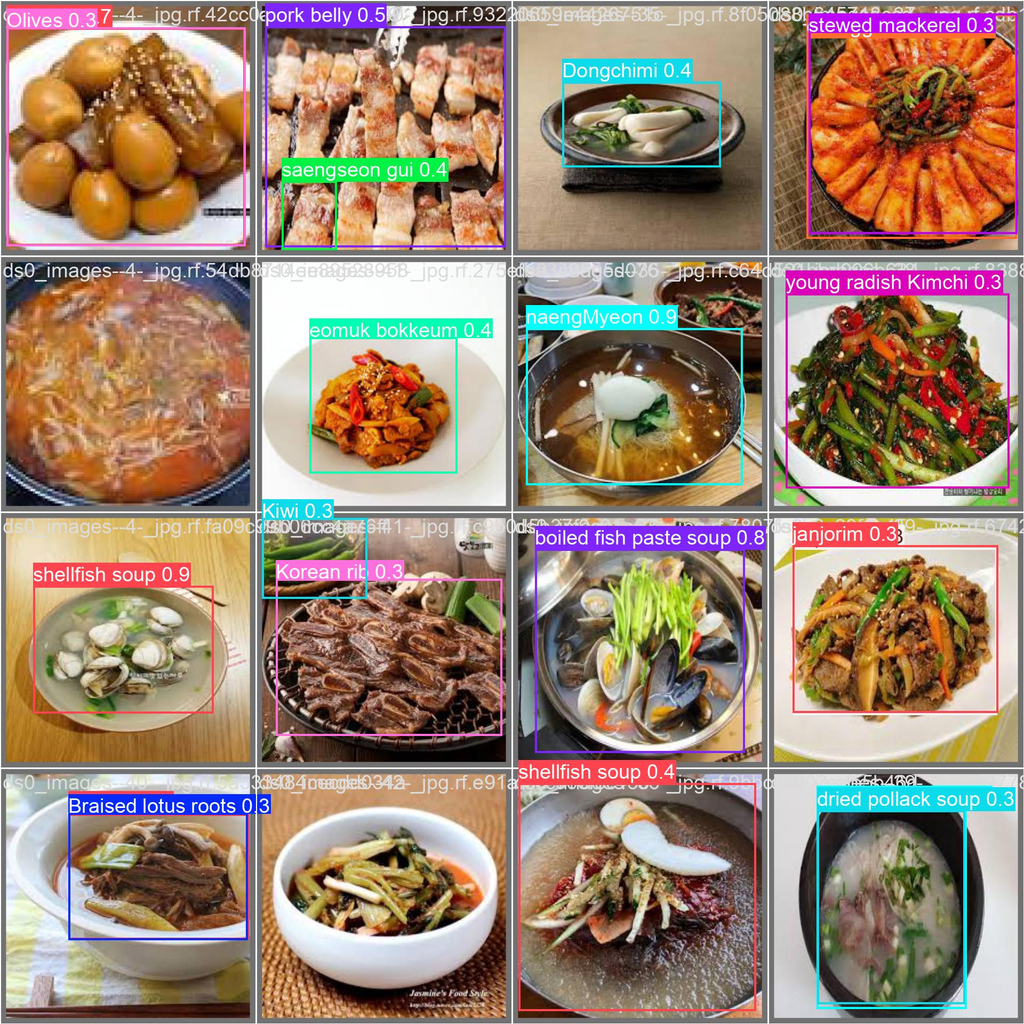

```python
# Validation 샘플
display(Image(filename=f'{result_dir}/val_batch2_pred.jpg', width=800))
```

## 6. ONNX Export

```python
best_model = YOLO(f'{result_dir}/weights/best.pt')

best_model.export(
    format='onnx',
    opset=13,
    simplify=True,
)

print(f'\nExport 완료: {result_dir}/weights/best.onnx')
```

```
Ultralytics 8.4.33 🚀 Python-3.12.13 torch-2.10.0+cu128 CPU (Intel Xeon CPU @ 2.20GHz)
💡 ProTip: Export to OpenVINO format for best performance on Intel hardware. Learn more at https://docs.ultralytics.com/integrations/openvino/
Model summary (fused): 73 layers, 3,377,387 parameters, 0 gradients, 9.8 GFLOPs

PyTorch: starting from 'runs/detect/food_detect/yolov8n_merged/weights/best.pt' with input shape (1, 3, 640, 640) BCHW and output shape(s) (1, 225, 8400) (6.7 MB)
requirements: Ultralytics requirements ['onnx>=1.12.0,<2.0.0', 'onnxslim>=0.1.71', 'onnxruntime-gpu'] not found, attempting AutoUpdate...
Using Python 3.12.13 environment at: /usr
Resolved 12 packages in 334ms
Prepared 4 packages in 3.14s
Installed 4 packages in 298ms
 + colorama==0.4.6
 + onnx==1.21.0
 + onnxruntime-gpu==1.24.4
 + onnxslim==0.1.90

requirements: AutoUpdate success ✅ 4.4s
WARNING ⚠️ requirements: Restart runtime or rerun command for updates to take effect


ONNX: starting export with onnx 1.21.0 opset 13...
ONNX: slimming with onnxslim 0.1.90...
ONNX: export success ✅ 5.9s, saved as 'runs/detect/food_detect/yolov8n_merged/weights/best.onnx' (13.1 MB)

Export complete (6.2s)
Results saved to /content/runs/detect/food_detect/yolov8n_merged/weights
Predict:         yolo predict task=detect model=runs/detect/food_detect/yolov8n_merged/weights/best.onnx imgsz=640
Validate:        yolo val task=detect model=runs/detect/food_detect/yolov8n_merged/weights/best.onnx imgsz=640 data=/content/merged_dataset/data.yaml
Visualize:       https://netron.app

Export 완료: runs/detect/food_detect/yolov8n_merged/weights/best.onnx
```

```python
import onnx, os

onnx_path = f'{result_dir}/weights/best.onnx'
m = onnx.load(onnx_path)

print(f'Opset: {m.opset_import[0].version}')
print(f'Input: {m.graph.input[0].name} {[d.dim_value or d.dim_param for d in m.graph.input[0].type.tensor_type.shape.dim]}')
print(f'Output: {m.graph.output[0].name} {[d.dim_value or d.dim_param for d in m.graph.output[0].type.tensor_type.shape.dim]}')
print(f'Size: {os.path.getsize(onnx_path) / 1024 / 1024:.1f} MB')
```

```
Opset: 13
Input: images [1, 3, 640, 640]
Output: output0 [1, 225, 8400]
Size: 13.1 MB
```

## 7. 라벨 목록 출력

앱의 `labels.ts`를 교체할 라벨 배열을 생성합니다.

```python
names = best_model.names

print(f'// {len(names)} classes')
print('export const LABELS: string[] = [')
for idx in sorted(names.keys()):
    print(f"\t'{names[idx]}',")
print('];')
```

```
// 221 classes
export const LABELS: string[] = [
	'Braised lotus roots',
	'Dongchimi',
	'Japchae',
	'Kimchi stew',
	'Kimchi',
	'Korean rib',
	'Korean style raw beef',
	'seasoned bean sprouts',
	'Udon',
	'baek Kimchi',
	'banquet noodles',
	'bean sprout soup',
	'beef-bone soup',
	'bellflower greens',
	'bibimbap',
	'boiled fish paste soup',
	'budaejjigae',
	'bulgogi',
	'chonggak Kimchi',
	'cucumber kimchi',
	'cup rice',
	'dried pollack soup',
	'eel',
	'fried rice',
	'green onion Kimchi',
	'grilled mackerel',
	'janjorim',
	'jeyuk bokkeum',
	'memil soba',
	'miso soup',
	'mixed rice',
	'nabak Kimchi',
	'naengMyeon',
	'pickled sesame leaf',
	'pig hocks',
	'pork belly',
	'radish Kimchi',
	'radish kimchi',
```

[output cut: 169 more lines]

```
	'ramyeon',
	'saengseon gui',
	'samgyetang',
	'sannakji',
	'sigeumchi muchim',
	'soju',
	'sundae',
	'sundae gukbap',
	'suyuk',
	'tangsuyuk',
	'tteokbokki',
	'twigim',
	'yangpa jangajji',
	'yukhoe',
];
```

## 8. 다운로드

```python
from google.colab import files

files.download(f'{result_dir}/weights/best.onnx')
files.download(f'{result_dir}/weights/best.pt')
```

## 다음 단계

1. 다운로드한 `best.onnx`를 `static/model.onnx`로 교체
2. 위에서 출력된 라벨 배열로 `src/lib/onnx/labels.ts` 교체
3. `src/lib/onnx/session.ts`의 `NUM_CLASSES`를 새 클래스 수로 변경
4. `npm run dev`로 테스트

### 추가 데이터셋 병합 시

1. `DATASETS` 리스트에 새 데이터셋 추가
2. 이 노트북을 처음부터 다시 실행
3. 클래스 재매핑이 자동으로 처리됨